# Anomalías térmicas en Costa Rica — VIIRS NOAA-21

Detecciones del sensor VIIRS a bordo de NOAA-21 (VIIRS_NOAA21_NRT de NASA FIRMS)

Autor/a

Organización Incendios Forestales

Fecha de publicación

15 de septiembre de 2026

## Introducción

Este reporte presenta las anomalías térmicas (detecciones de fuego activo) registradas por el sensor **VIIRS** a bordo del satélite **NOAA-21** en el territorio continental de **Costa Rica**. Es el cuarto de una serie de reportes equivalentes, junto con los de MODIS, VIIRS en Suomi-NPP y VIIRS en NOAA-20. El ámbito es **continental** (sin la Isla del Coco) y el límite nacional es la unión de las siete provincias de la cartografía oficial 1:5000 del IGN; los detalles están en el reporte MODIS.

NOAA-21 es la plataforma más reciente de la constelación VIIRS y lleva el mismo instrumento que Suomi-NPP y NOAA-20, con píxel de 375 m en las bandas de imagen. Como las demás, se publica como serie propia: sus detecciones no se suman a las de las otras plataformas, porque más satélites en órbita significan más oportunidades de observación y una serie combinada mostraría un salto que refleja el instrumental disponible y no el régimen de fuego.

El período analizado va del **17/01/2024** al **13/09/2026**, con un total de **13 135** detecciones dentro del país.

### Tres advertencias propias de esta plataforma

Este reporte se lee distinto de los otros tres, por tres razones que conviene tener presentes desde el principio.

**Primera: todos sus datos son provisionales.** NOAA-21 es la única de las cuatro plataformas que **no tiene procesamiento estándar**. El producto `VIIRS_NOAA21_NRT` es todo lo que existe y no hay fecha prevista para una versión definitiva. Los datos en tiempo casi real se publican en horas, pero su geolocalización y su filtrado de falsas alarmas se refinan cuando la NASA los reprocesa; en las otras plataformas ese reproceso llega, aquí no. En consecuencia, **las cifras de este reporte pueden cambiar entre corridas** y no son estrictamente reproducibles. Las de los otros tres reportes sí lo son, salvo en su tramo final.

**Segunda: el registro es corto.** Arranca en 2024 y cubre apenas dos estaciones secas y media, con **33** meses activos de 33. Con un registro así, un episodio grande mueve cualquier porcentaje, de modo que aquí las cifras se acompañan siempre de su número de casos y la climatología mensual —que en los otros reportes promedia sobre una o dos décadas— se apoya en apenas dos o tres años por mes.

**Tercera: el área quemada es prestada.** NOAA-21 tampoco tiene producto de área quemada propio, así que este reporte usa **VNP64A1, derivado de Suomi-NPP**, recortado al período de NOAA-21 y rotulado como «VNP64A1, S-NPP» en cada figura, tabla y leyenda. Es la misma decisión que en el reporte de NOAA-20: el área quemada es una medición distinta —la superficie que quedó marcada, en píxeles de 500 m— y no detecciones de otro sensor mezcladas con las de este. Pero al comparar las dos series de un mismo gráfico se están comparando dos plataformas.

## Mapa animado

Detecciones mensuales de anomalías térmicas; el color indica la potencia radiativa del fuego (FRP).

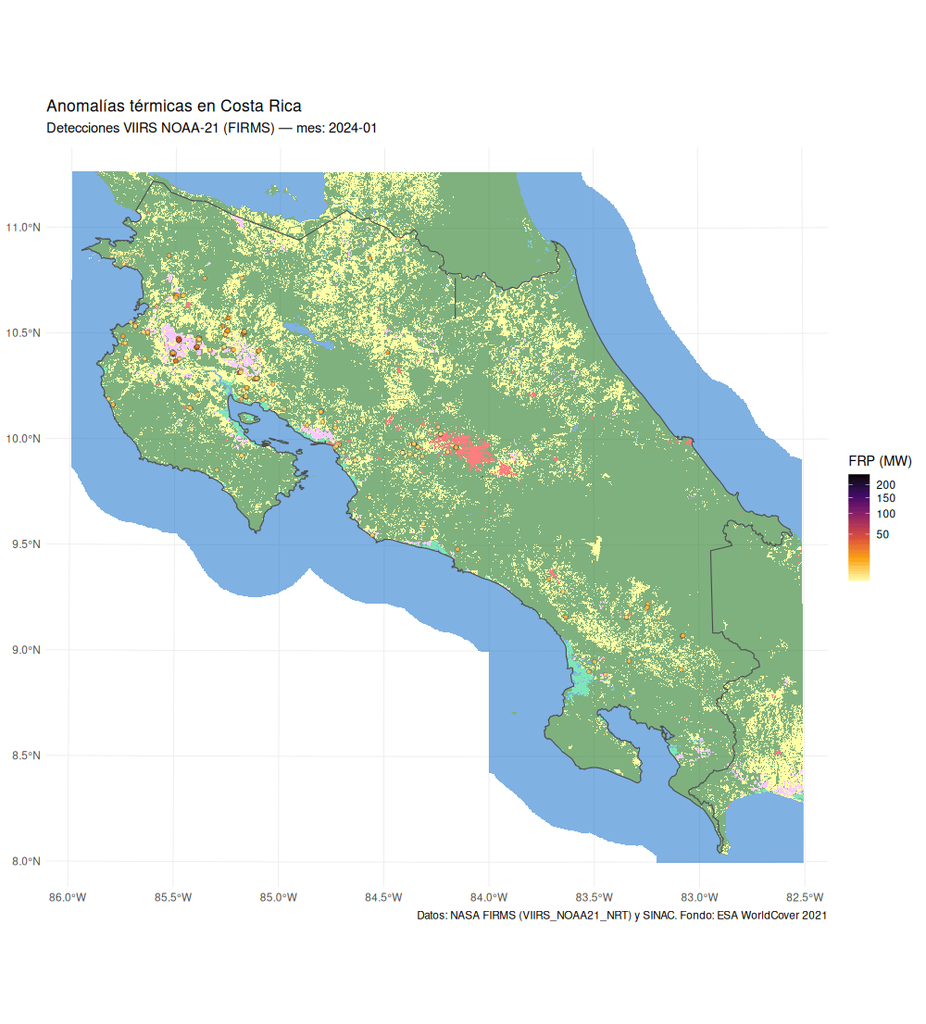

## Video resumen

Resumen mensual en formato de video: detecciones de fuego activo (VIIRS NOAA-21) con su estela de los meses recientes y píxeles de área quemada (VNP64A1, de Suomi-NPP), sobre el relieve del país teñido por la cobertura de la tierra (WorldCover 2021). El video termina en el último mes con producto de área quemada, porque sus dos contadores son acumulados sincronizados; el mapa interactivo y las series sí llegan hasta el final del registro.

[video not shown]

El cartel estático resume las dos series mensuales. A diferencia del video, conserva el eje completo y marca con una banda el tramo que todavía no tiene producto de área quemada.

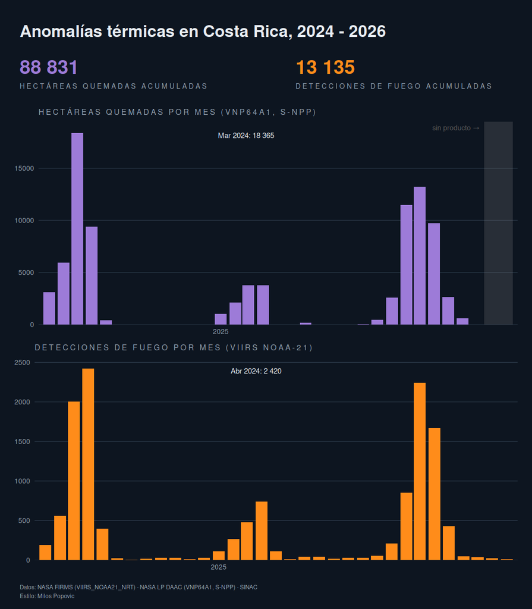

## Mapa interactivo

[interactive chart not shown]

## Estadísticas

### Serie temporal mensual

Detecciones de fuego activo (arriba) y hectáreas quemadas (abajo), con el eje temporal compartido. Las dos series son complementarias y **no sumables**, y en este reporte provienen además de plataformas distintas. La banda gris del panel inferior marca los meses sin producto de área quemada: no son ceros.

[interactive chart not shown]

### Climatología mensual

Promedios por mes calendario. **Léase con cautela**: con dos estaciones secas y media de registro, cada promedio mensual se apoya en dos o tres valores, y un episodio grande basta para dominar su mes.

[interactive chart not shown]

### Resumen anual

| Año | Detecciones | Hectáreas quemadas | FRP promedio (MW) | FRP máximo (MW) |
| --- | --- | --- | --- | --- |
| 2024 | 5704 | 37221 | 7.9 | 242.96 |
| 2025 | 1911 | 11395 | 8 | 119.26 |
| 2026 | 5520 | 40215 | 7.6 | 208.67 |

## Detecciones por área de conservación

Cada detección se asigna al **área de conservación** del [SINAC](https://www.sinac.go.cr/) donde cae su punto; cada píxel de área quemada, a la del centroide del píxel. Con un registro tan corto, la distribución refleja las estaciones secas de 2024–2026 y no un patrón de largo plazo.

[interactive chart not shown]

| Siglas | Área de conservación | Detecciones | % del total | Hectáreas quemadas |
| --- | --- | --- | --- | --- |
| ACT | Tempisque | 4543 | 34.6 | 34399 |
| ACAT | Arenal Tempisque | 2611 | 19.9 | 23838 |
| ACG | Guanacaste | 2332 | 17.8 | 24544 |
| ACAHN | Huetar Norte | 951 | 7.2 | 1967 |
| ACOPAC | Pacifico Central | 768 | 5.8 | 2116 |
| ACLAP | La Amistad Pacifico | 743 | 5.7 | 449 |
| ACC | Central | 685 | 5.2 | 299 |
| ACLAC | La Amistad Caribe | 218 | 1.7 | 385 |
| ACOSA | Osa | 208 | 1.6 | 43 |
| Sin asignar | Sin asignar | 39 | 0.3 | 791 |

[output cut: 1 more lines]

La distribución por año y área de conservación está disponible como CSV.

## Cobertura de la tierra

Cada detección corresponde a un píxel de 375 m en el nadir, por lo que la cobertura se caracteriza sobre el *footprint* completo de la detección —una elipse con las dimensiones reales del píxel— y no sobre el punto exacto.

**Limitación**: WorldCover describe la cobertura de 2021 y el registro abarca 2024–2026.

[interactive chart not shown]

El gráfico gemelo muestra las hectáreas quemadas según la clase dominante del píxel de VNP64A1 (Suomi-NPP).

[interactive chart not shown]

### Contraste con el Registro Nacional de Humedales

| Clase WorldCover | Detecciones | En humedal | % en humedal | Fracción del footprint en humedal | Hectáreas quemadas | % del área quemada en humedal |
| --- | --- | --- | --- | --- | --- | --- |
| Bosque | 9215 | 302 | 3.3 | 0.01 | 46415 | 1.2 |
| Pastizal | 3016 | 442 | 14.7 | 0.094 | 20695 | 13.9 |
| Cultivos | 640 | 44 | 6.9 | 0.027 | 21358 | 4.5 |
| Zonas construidas | 150 | 1 | 0.7 | 0.001 | 0 |  |
| Suelo desnudo / vegetación escasa | 52 | 50 | 96.2 | 0.295 | 0 |  |
| Cuerpos de agua | 33 | 18 | 54.5 | 0.269 | 171 | 37.5 |
| Manglar | 19 | 11 | 57.9 | 0.264 | 192 | 22.2 |
| Humedal herbáceo | 8 | 8 | 100 | 0.925 | 0 |  |
| Matorral | 2 | 0 | 0 | 0 | 0 |  |

De las **3 016** detecciones cuyo footprint domina el *pastizal* de WorldCover, el **14,7 %** cae dentro de un humedal registrado (con un **9 %** del footprint cubierto por humedal, en promedio). El polígono del registro que más detecciones concentra es *Sector Catalina 1*, con 117. Con un registro corto, estas cifras dependen mucho de los episodios que tocó observar.

Vale la advertencia habitual sobre la clase de humedal: el registro asigna una sola clase por polígono; `clase_hum` describe el tipo de humedal *como sitio* y no la cobertura en cada punto de su extensión.

## El episodio del humedal Catalina, mayo de 2026

Un registro tan corto como el de NOAA-21 se entiende mejor a través de un episodio concreto. El 28 de mayo de 2026 la caída de un rayo encendió el interior del humedal Catalina (Parque Nacional Palo Verde, cuenca baja del Tempisque) y una semana después Delfino.cr reportaba, con cifras del Minae-Sinac, que el fuego había afectado **cerca de 4 000 hectáreas** ([nota del 3 de junio de 2026](https://delfino.cr/2026/06/incendio-en-parque-nacional-palo-verde-afecto-cerca-de-4000-hectareas)). El combustible principal fue la *Typha*, una planta invasora que arde incluso sobre el agua. Es el único episodio del registro con una fecha de ignición, una causa y una superficie oficial conocidas: la ocasión de contrastar el satélite contra algo medido en tierra.

**Lo que vio esta plataforma.** NOAA-21 registró **126 detecciones** en la ventana del evento, en 4 días, del 30 de mayo al 2 de junio de 2026 —el fuego apareció en las imágenes 2 días después de la ignición reportada—, con una potencia radiativa acumulada de 1 987 MW y un máximo de **132,8 MW**, el valor más alto que registró cualquiera de las cuatro plataformas durante el incendio. 49 de esas detecciones son nocturnas, la proporción más alta de las cuatro: el fuego no se apagaba de noche y NOAA-21 quedó bien situada para verlo.

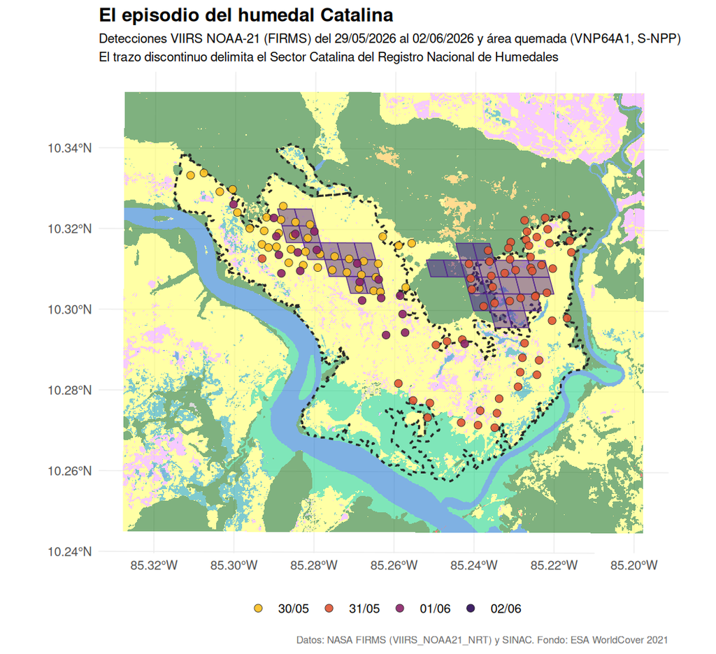

**Dónde ardió.** El **91,3 %** de las detecciones del episodio tiene como polígono dominante el *Sector Catalina* del Registro Nacional de Humedales, y el **84,1 %** cae en footprints donde WorldCover ve *pastizal*: un ejemplo concreto de que parte del “pastizal” que arde en Costa Rica es humedal estacional y no potrero, y esta vez la fuente periodística precisa que lo que ardió fue un typhal sobre agua.

**Lo que el área quemada no vio.** Para mayo y junio de 2026, VNP64A1, S-NPP marca **3228 hectáreas** quemadas en la zona del evento, frente a las 4 000 reportadas oficialmente: el producto satelital ve **1,2 veces menos superficie** que la contabilizada en tierra.

VNP64A1, S-NPP declara quemado un píxel de 500 m cuando detecta un **cambio persistente de reflectancia**, y una quema de *Typha* sobre lámina de agua no lo produce: la vegetación emergente desaparece, el agua vuelve a dominar la señal y a las pocas semanas la superficie se parece a lo que era antes. A eso se suma que el píxel de 500 m no resuelve las cicatrices delgadas e interrumpidas que deja un fuego que avanza entre canales. No es un defecto de este episodio sino el comportamiento esperable del algoritmo en humedales, y advierte contra leer las hectáreas de la tabla anual como una medida de la superficie realmente afectada: **sirven para comparar años entre sí, no para responder cuántas hectáreas se quemaron.**

**Qué tan excepcional es.** Con 428 detecciones, mayo de 2026 está entre los meses más intensos de los 33 del registro de esta plataforma. Es también la ilustración de la segunda advertencia de la introducción: con un registro de dos años y medio, los episodios grandes dominan los porcentajes, así que conviene releer el reporte con eso en mente.

## Fuentes de datos

- **NASA FIRMS** — Fire Information for Resource Management System, producto VIIRS_NOAA21_NRT (VIIRS 375 m, NOAA-21/JPSS-2, tiempo casi real; **no existe versión de procesamiento estándar**). https://firms.modaps.eosdis.nasa.gov/.
- **NASA LP DAAC** — producto de área quemada VNP64A1 v002 (VIIRS/NPP, mensual, 500 m), **derivado de Suomi-NPP**: no existe equivalente de NOAA-21. Giglio, L., y Justice, C. (2021). *VNP64A1 VIIRS/NPP Burned Area Monthly L4 Global 500m SIN Grid V002*, DOI: 10.5067/VIIRS/VNP64A1.002.
- **IGN / SNIT** — cartografía oficial 1:5000: límite provincial (la unión de las siete provincias es el límite nacional del análisis). https://www.snitcr.go.cr/.
- **SINAC** — capas de áreas de conservación y Registro Nacional de Humedales (2016–2018), de su servicio WFS. https://geos1pne.sirefor.go.cr/wfs.
- **ESA WorldCover** — cobertura de la tierra 2021 a 10 m, v200. https://esa-worldcover.org/. Zanaga, D., et al. (2022). *ESA WorldCover 10 m 2021 v200*, DOI: 10.5281/zenodo.7254221.

Los reportes análogos: MODIS, VIIRS en Suomi-NPP y VIIRS en NOAA-20.

El código de este análisis está disponible en https://github.com/incendios-forestales/anomalias-termicas-costarica.